```
████████╗███████╗███████╗████████╗    ███████╗███╗   ██╗████████╗██████╗  ██████╗ ██████╗ ██╗   ██╗
╚══██╔══╝██╔════╝██╔════╝╚══██╔══╝    ██╔════╝████╗  ██║╚══██╔══╝██╔══██╗██╔═══██╗██╔══██╗╚██╗ ██╔╝
   ██║   █████╗  ███████╗   ██║       █████╗  ██╔██╗ ██║   ██║   ██████╔╝██║   ██║██████╔╝ ╚████╔╝
   ██║   ██╔══╝  ╚════██║   ██║       ██╔══╝  ██║╚██╗██║   ██║   ██╔══██╗██║   ██║██╔═══╝   ╚██╔╝
   ██║   ███████╗███████║   ██║       ███████╗██║ ╚████║   ██║   ██║  ██║╚██████╔╝██║        ██║
   ╚═╝   ╚══════╝╚══════╝   ╚═╝       ╚══════╝╚═╝  ╚═══╝   ╚═╝   ╚═╝  ╚═╝ ╚═════╝ ╚═╝        ╚═╝
```

# BENFORD’S LAW IN CRIME RATES ACROSS MEXICAN STATES

This test was inspired by **University of Chicago** https://bit.ly/2sQSJKX

# Introduction

## a) Benford's Law

Frank Benford made the observation in 1938, after Simon Newcomb did it in 1881, that in a large number of different data sets the probability that the leading significant digit, d, in a number from a data set to be:

#### **Equation 0:** $P(d)=log_{10}(1+1/d)$

This rule of thumb has become known as Benford’s Law and although does not hold for all data sets, it does work surprisingly often. This regularity has been used to detect fraud in expense reports, vendor payments, elections, macro economic data, etc.

More about Benford's Law:

https://bit.ly/2PoKhLX

https://bit.ly/2Z3gKL7

## b) Crime Rates in Mexico (SNSP)

The Sistema Nacional de Seguridad Pública (SNSP) publishes a dataset containing monthly crime data for every municipality in Mexico. This dataset will be the subject of this analysis and the goal is to address whether crime data at state level satisfies Benford's Law or not.

Two datasets are provided:

1) **snsp_municipal_2015_2019.xlsx** | containing monthly data on the number of crimes in every municipality in Mexico since 2015, for a set of 98 types of crime. You can assume that numbers in column 'Mes' represent months from January to December, as well as numbers in the column 'Clave_Ent' represent states from Aguascalientes to Zacatecas.

2) **delitos.xlsx** | containing descriptions for crime codes used in snsp_municipal_2015_2019.xlsx

## c) Objective of the test

In this test, you will develop code to calculate the expected and actual Benford's distribution of the leading significant digits from the SNSP dataset at state level. We will provide some auxiliary functions and specify a set of specific functions that you must implement.

# Task 1: Extracting leading digits

The first task is to complete the function extract_leading_digits. This function should take a number and a number of digits as inputs and return an integer containing the specified number of leading digits.

```
Examples of extract_leading_digits:
-------------------------------------------------------------
inputs: number, number of digits        |      otputs
-------------------------------------------------------------
extract_leading_digits(245, 1)          |      2
extract_leading_digits(.245, 2)         |      24
extract_leading_digits(.0000245, 3)     |      245
-------------------------------------------------------------
```

### Hint:

The leading digit of a number can be extracted implementing the following formula:

#### leading_digits(number_as_float, num_digits) = $trunc(10^{x} * number\_as\_float)$

where:  
$\qquad number\_as\_float$ is the float of a number  
$\qquad x = -⌊log_{10}(number\_as\_float)⌋ + num\_digits - 1$  
$\qquad trunc(z)$ throws away the fractional part of $z$ you can use math.trunc  
$\qquad ⌊z⌋$ computes largest integer $\leq z$ you can use math.floor  
$\qquad log_{10}(z)$ computes the base-10 logarithm of $z$ you can use math.log10

```python
def extract_leading_digits(number, num_digits):
```

#### If your implementation of extract_leading_digits is correct, the following code will print 'CORRECT!', otherwise it will print 'FAIL!'

```python
fails = 0
test_values = {245: (1, 2), .245: (2, 24), .0000245: (3, 245)}
for k, v in test_values.items():
    num_digits, true_value = v
    diff = extract_leading_digits(k, num_digits) - true_value
    fails += diff
if fails == 0:
    print('CORRECT!')
else:
    print('FAIL!')
```

# Task 2: Compute leading digit range

Your second task is to complete the function get_leading_digits_range, which takes the number of leading digits and returns a tuple with the lower bound (inclusive) and upper bound (exclusive) on the range of the values for that number of leading digits. For example, when called with a value of 2, the range of possible values (inclusive) is 10,..,99, so the function should return the tuple (10, 100).

```python
def get_leading_digits_range(num_digits):
```

# Task 3: Compute expected Benford distribution

The third task is to complete the function compute_expected_benford_dist, which takes the number of digits as an argument and returns a list of floats with the expected distribution according to **Equation 0**. The implementation of this function can be done with a simple loop to construct the desired list. You must call your get_leading_digits_range function to determine the range of of possible values for the specified number of digits.

```python
def compute_expected_benford_dist(num_digits):
```

#### The following are correct results of the calling compute_expected_benford_dist(1)

```
leading digit   |   probability according to Benford's Law
----------------------------------------------------------
      1         |           0.30102999566398120
      2         |           0.17609125905568124
      3         |           0.12493873660829993
      4         |           0.09691001300805642
      5         |           0.07918124604762482
      6         |           0.06694678963061322
      7         |           0.05799194697768673
      8         |           0.05115252244738129
      9         |           0.04575749056067514
```

#### We provide a function to visualize the results of compute_expected_benford_dist(1)

```python
import matplotlib.pyplot as plt
def plot_benford(benford_distribution_list):
    X = list(range(1, len(benford_distribution_list) + 1))
    plt.xticks([])
    plt.bar(X, benford_distribution_list)
    plt.show()
```

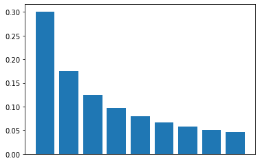

```python
correct_benford_1 = [0.30102999566398120,
                     0.17609125905568124,
                     0.12493873660829993,
                     0.09691001300805642,
                     0.07918124604762482,
                     0.06694678963061322,
                     0.05799194697768673,
                     0.05115252244738129,
                     0.04575749056067514]

plot_benford(correct_benford_1)
```

# Task 4: Computing the Benford distribution

Your fourth task is to complete the function compute_benford_dist, which takes a non-empty list of numbers representing total crimes by state and a number of digits as arguments. It should compute the Benford distribution of the given data for the specified number of leading digits.

Your implementation will need to determine the number of times each value in the range of leading digits occurs, using a list to hold the counts, and then generate a list with the distribution from the counts.

You will need to determine the number of values in the range of leading digits. Use your get_leading_digits_range function to determine the range. Use the function you wrote for task 1 to extract leading digits.

```python
def compute_benford_dist(list_of_numbers, num_digits):
```

# Putting it all together with SNSP dataset

### You don't have to worry about implementing your results* from tasks 1 to 4 to the SNSP dataset.

The following lines of code:

```
1) import SNSP datasets,

2) allow you implement functions from tasks 1-4 to them

3) plot the results for specific states and years,
   comparing actual and expected Benford distributions
```

*/ Note that function compute_benford_dist_entidad_año we provide, depends entirely on the correct implementation of compute_benford_dist from task 4

```python
import pandas as pd

delitos = pd.read_excel('./delitos.xlsx')
snsp = pd.read_excel('./snsp_municipal_2015_2019.xlsx') # this takes a few minutes to run

def extract_snsp_entidad(snsp_df, entidad):
    rv = snsp_df.loc[snsp_df['Clave_Ent'] == entidad]
    rv = rv.reset_index(drop=True)
    return rv

def extract_snsp_año(snsp_df, año):
    rv = snsp_df.loc[snsp_df['Año'] == año]
    rv = rv.reset_index(drop=True)
    return rv

def compute_benford_dist_entidad_año(snsp_df, entidad, año, num_digits):
    info_columns = ['Año', 'Mes', 'Clave_Ent', 'Clave_Mun']
    df = extract_snsp_entidad(snsp_df, entidad)
    df = extract_snsp_año(df, año)
    list_of_numbers = []
    for i in range(len(df)):
        for c in df.columns:
            if c not in info_columns:
                number = df[c][i]
                if number != 0:
                    list_of_numbers.append(number)
    rv = compute_benford_dist(list_of_numbers, num_digits)
    return rv

def plot_benford_vs_expected(benford_distribution_list, expected_benford_distribution_list, entidad):
    X = list(range(1, len(benford_distribution_list) + 1))
    plt.title('State code: {}'.format(entidad))
    plt.xticks([])
    plt.bar(X, benford_distribution_list)
    plt.plot(X, expected_benford_distribution_list, color='red', linewidth=5)
    plt.show()
```

### In order to test the code defined above, for state 1 (Aguascalientes) in 2015, you need to run:

Again, it works only if your implementation of compute_benford_dist from task 4 is correct

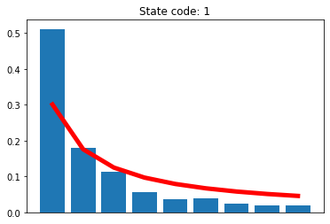

```python
entidad = 1
año = 2015
num_digits = 1
expected_benford = compute_expected_benford_dist(num_digits)
benford = compute_benford_dist_entidad_año(snsp, entidad, año, num_digits)
plot_benford_vs_expected(benford, expected_benford, entidad)
```

# Some final questions:

Please briefly answer:

how does the Benford distribution behaves for states 2 (Baja California) and 30 (Veracruz)?

What do you think explain the differences between these two states?

How powerful is Benford's Law to detect potential fraud in this setting (SNSP is fed by Procuradurías Estatales and they could be lying about the real amount of crime in their regions)

HARD: what would you need to modify in function compute_benford_dist_entidad_año to create an alternative function compute_benford_dist_delito_año that analyzes not by state but rather by type of crime across states